# ProblemSet6

Question1

#### a) The number below is the average ratio of government spending.

```python
import numpy
import pandas
#downloading datset
govExp=pandas.DataFrame.from_csv("GCEC1.csv")
GDP=pandas.DataFrame.from_csv("GDPC1.csv")
ratio=govExp["GCEC1"]/GDP["GDPC1"]
print(numpy.average(ratio))
print(numpy.average(govExp))
```

```
0.245504910667
2067.22565217
```

#### b) I am using scipy library to detrend data and statsmodels to fit AR(1) process

```python
%matplotlib inline
from scipy.signal import detrend
import matplotlib.pyplot as plt
from statsmodels.tsa.ar_model import AR
detrended=detrend(govExp["GCEC1"])
ar = AR(detrended)
model_fit=ar.fit(maxlag=1)
print('Coefficients: %s' % model_fit.params)
print('Standard deviation of innovation: %s' % model_fit.sigma2**(1/2))
```

```
Coefficients: [-1.04313218  0.99754253]
Standard deviation of innovation: 18.2663109483
```

## c) Writing down the Lagrangian parts of lagrangian relevant for the maximization:

$L=E_{0}[\beta^{t}(ln c_{t}+\theta ln(1-n_t))-\lambda_{t} (c_{t}+k_{t+1}-(1-\delta)k_{t}+(b_{t+1}-b_{t}- [w_{t}n_{t}+R_{t}k_{t}+\pi_{t}-T_{t}+r_{t}b_{t}]))- \lambda_{t+1} (c_{t+1}+k_{t+2}-(1-\delta)k_{t+1}+(b_{t+2}-b_{t+1}- [w_{t+1}n_{t+1}+R_{t+1}k_{t+1}+\pi_{t+1}-T_{t+1}+r_{t+1}b_{t+1}]))]$

Taking the first order conditions:

$\frac{\partial L}{\partial k_{t+1}}=E_0[-\lambda_{t}-\lambda_{t+1}[-(1-\delta)-R_{t+1}]]=0$

$\frac{\partial L}{\partial b_{t+1}}=E_0[-\lambda_{t}-\lambda_{t+1}[-1-r_{t+1}] ]=0$  
$\frac{\partial L}{\partial n_{t}}=E_0[-\beta^{t} \theta \frac{1}{1-n_t}+\lambda_{t} w_{t}]=0$  
$\frac{\partial L}{\partial c_{t}}=E_0[\beta^{t} \frac{1}{c_t}-\lambda_{t}]=0$

d) Bond market clears if number of bonds issued by govenment $d_t$ is equal to consumers demand $b_t$. Hence, the bond market clearing condition is $b_t=d_t$

### e) The government budget constraint: $g_t+(d_{t+1}-d_t)=T_t+r_t d_t$, becomes

$g_t+(b_{t+1}-b_t)=T_t+r_t b_t$. Rewriting the government constraint:  
$b_{t+1}=T_t+r_t b_t+b_t-g_t=T_t-g_t+(1+r_t)b_t$. Substituting into the budget constraint: $c_{t}+k_{t+1}-(1-\delta)k_{t}+b_{t+1}-b_{t}= w_{t}n_{t}+R_{t}k_{t}+\pi_{t}-T_{t}+r_{t}b_{t}$  
$c_{t}+k_{t+1}-(1-\delta)k_{t}+T_t-g_t+(1+r_t)b_t-b_{t}= w_{t}n_{t}+R_{t}k_{t}+\pi_{t}-T_{t}+r_{t}b_{t}$ ,which simplifies to  
$c_{t}+k_{t+1}-(1-\delta)k_{t}+T_t-g_t= w_{t}n_{t}+R_{t}k_{t}+\pi_{t}-T_{t}$ , which does not have $b_t$ in it.  
I do not know how to prove ii.

### f) Taking the first order conditions:

$\frac{\partial \Pi_t}{\partial k_{t}}=\alpha a_t (\frac{n_t}{k_t})^{1-\alpha} - R_t=0$  
$\frac{\partial \Pi_t}{\partial n_{t}}=(1-\alpha) a_t (\frac{k_t}{n_t})^{\alpha} - w_t=0$

### g) Writing down the equations of the model in full:

1)$E_0[-\lambda_{t}-\lambda_{t+1}[-(1-\delta)-R_{t+1}]]=0$

2)$E_0[-\lambda_{t}-\lambda_{t+1}[-1-r_{t+1}] ]=0$  
3)$E_0[-\beta^{t} \theta \frac{1}{1-n_t}+\lambda_{t} w_{t}]=0$  
4)$E_0[\beta^{t} \frac{1}{c_t}-\lambda_{t}]=0$

5)$\alpha a_t (\frac{n_t}{k_t})^{1-\alpha} - R_t=0$

6)$(1-\alpha) a_t (\frac{k_t}{n_t})^{\alpha} - w_t=0$  
7)$g_t+(d_{t+1}-d_t)=T_t+r_t d_t$  
8)$c_{t}+k_{t+1}-(1-\delta)k_{t}+b_{t+1}-b_{t}= w_{t}n_{t}+R_{t}k_{t}+\pi_{t}-T_{t}+r_{t}b_{t}$

9)$b_t=d_t$

10)$ln g_t=(1-\rho_g)(ln \psi+ln y^{*})+\rho_g ln g_{t-1}+\epsilon_t$

11)$ln a_t=\rho ln a_{t-1}+\epsilon_{a,t}$

From 4: $\beta^{t} \frac{1}{c_t}=\lambda_{t}$

From 1: $-\lambda-\beta*\lambda[-(1-\delta)-R]=-1+\beta+\beta R-\beta \delta=0$ implying $R=1/ \beta -1+\delta$  
From 2 similar to 1: $r=1/ \beta -1$

From 1,5: $\alpha a_t (\frac{n}{k})^{1-\alpha}=1/ \beta -1+\delta$

From 11: $a=1$

From 10: $g=\psi y^{*}$  
Reducing the system by sustituting values into 3,8:  
8: $c_{t}+k_{t}-(1-\delta)k_{t}+T_t-g_t= w_{t}n_{t}+R_{t}k_{t}+\pi_{t}-T_{t}$

$c_t+(\delta-R_t)K_t=w_t n_t +\pi_t -g_t$

$-\beta^{t} \theta \frac{1}{1-n_t}+\beta^{t} \frac{1}{c_t} w_{t}=0$  
13) $-\beta^{t} \theta \frac{1}{1-n_t}+\beta^{t} \frac{1}{c_t} (1-\alpha) a_t (\frac{k_t}{n_t})^{\alpha}=0$  
14) $c_t+(\delta-\alpha a_t (\frac{n_t}{k_t})^{1-\alpha})K_t=(1-\alpha) a_t (\frac{k_t}{n_t})^{\alpha} n_t -\psi y^{*}$

15) $\alpha a_t (\frac{n_t}{k_t})^{1-\alpha}=1/ \beta -1+\delta$  
16) $n_t=1/3$ , giving 3 equations 3 unknowns.

$\alpha (\frac{n_t}{k_t})^{1-\alpha}=1/ \beta -1+\delta$  
16) Rewriting 15: $\frac{n_t}{k_t}=(\frac{1/ \beta -1+\delta}{\alpha})^{\frac{1}{1-\alpha}}$ , $k_t=(\frac{1/ \beta -1+\delta}{\alpha})^{\frac{1}{\alpha-1}} n_t$

17) $c_t+(\delta-\alpha (\frac{1/ \beta -1+\delta}{\alpha})K_t=(1-\alpha) (\frac{1/ \beta -1+\delta}{\alpha})^{\frac{-\alpha}{1-\alpha}} n_t -\psi y^{*}$

18) $-\beta^{t} \theta \frac{1}{1-n_t}+\beta^{t} \frac{1}{c_t} (1-\alpha) (\frac{1/ \beta -1+\delta}{\alpha})^{\frac{-\alpha}{1-\alpha}}=0$  
$ c_t=\frac{(1-\alpha)}{\theta} (\frac{1/ \beta -1+\delta}{\alpha})^{\frac{-\alpha}{1-\alpha}}(1-n_t)$

The 3 final equations are:  
1) $ c_t=\frac{(1-\alpha)}{\theta} (\frac{1/ \beta -1+\delta}{\alpha})^{\frac{-\alpha}{1-\alpha}}(1-n_t)$  
2) $k_t=(\frac{1/ \beta -1+\delta}{\alpha})^{\frac{1}{\alpha-1}} n_t$  
3) $c_t+(\delta-\alpha (\frac{1/ \beta -1+\delta}{\alpha}))K_t=(1-\alpha) (\frac{1/ \beta -1+\delta}{\alpha})^{\frac{-\alpha}{1-\alpha}} n_t -\psi y^{*}$

Substituting 1 and 2 into 3:  
$\frac{(1-\alpha)}{\theta} (\frac{1/ \beta -1+\delta}{\alpha})^{\frac{-\alpha}{1-\alpha}}(1-n_t)+(\delta-\alpha (\frac{1/ \beta -1+\delta}{\alpha})) ((\frac{1/ \beta -1+\delta}{\alpha})^{\frac{1}{\alpha-1}} n_t)=(1-\alpha) (\frac{1/ \beta -1+\delta}{\alpha})^{\frac{-\alpha}{1-\alpha}} n_t -\psi y^{*}$  
Putting n_t on one side:  
$[(1-\alpha) (\frac{1/ \beta -1+\delta}{\alpha})^{\frac{-\alpha}{1-\alpha}}+\frac{(1-\alpha)}{\theta} (\frac{1/ \beta -1+\delta}{\alpha})^{\frac{-\alpha}{1-\alpha}}-(\delta-\alpha (\frac{1/ \beta -1+\delta}{\alpha})) ((\frac{1/ \beta -1+\delta}{\alpha})^{\frac{1}{\alpha-1}}] n_t=\frac{(1-\alpha)}{\theta} (\frac{1/ \beta -1+\delta}{\alpha})^{\frac{-\alpha}{1-\alpha}}+\psi y^{*}$

Simplyfying the expression:

$[\frac{(1-\alpha)(\theta+1)}{\theta}(\frac{1/ \beta -1+\delta}{\alpha})^{\frac{-\alpha}{1-\alpha}}-\delta (\frac{1/ \beta -1+\delta}{\alpha})^{\frac{1}{\alpha-1}}+\alpha (\frac{1/ \beta -1+\delta}{\alpha})^{\frac{\alpha}{\alpha-1}}]n_t=\frac{(1-\alpha)}{\theta} (\frac{1/ \beta -1+\delta}{\alpha})^{\frac{-\alpha}{1-\alpha}}+\psi y^{*}$

$[\frac{(1-\alpha)(\theta+1)}{\theta}-\delta (\frac{1/ \beta -1+\delta}{\alpha})^{-1}+\alpha]n_t=\frac{(1-\alpha)}{\theta}+(\frac{1/ \beta -1+\delta}{\alpha})^{\frac{\alpha}{\alpha-1}} \psi y^{*}$, substituting in $n=1/3$:

$\frac{(1-\alpha)(\theta+1)}{3 \theta}-\frac{(1-\alpha)}{\theta}=1/3 [\delta (\frac{1/ \beta -1+\delta}{\alpha})^{-1}-\alpha]+(\frac{1/ \beta -1+\delta}{\alpha})^{\frac{\alpha}{\alpha-1}} \psi y^{*}$

$\frac{(1-\alpha)(\theta-2)}{3 \theta}=1/3 [\delta (\frac{1/ \beta -1+\delta}{\alpha})^{-1}-\alpha]+(\frac{1/ \beta -1+\delta}{\alpha})^{\frac{\alpha}{\alpha-1}} \psi y^{*}$

Taking first derivative over $\theta$ of the left-hand side:

$\frac{\partial LHS}{\partial \theta}=\frac{-3 \theta \alpha -3(1-\alpha)(\theta-2)}{9 \theta^{2}}=\frac{6-3\theta-6\alpha}{9 \theta^{2}}>0$ as long as $\theta<2(1-\alpha)$

**Given this information $\theta$ and $\psi$ are postiviely dependant if $\theta<2(1-\alpha)$ and negatively otherwise**

If willingnes to work is less than twice labour share of income, then higher share of government expenditure requires higher willingnes to work to achieve n=1/3. People must be induced to work more by higher taxes.

If people are willing to work, then they must be discouraged by decrease in taxation.

#### h) This part requires DYNARE

Rewriting the model in a way that it can be programmed in MATLAB:

1)$E_0[-\lambda_{t}-\lambda_{t+1}[-(1-\delta)-R_{t+1}]]=0$

2)$E_0[-\lambda_{t}-\lambda_{t+1}[-1-r_{t+1}] ]=0$  
3)$E_0[-\beta^{t} \theta \frac{1}{1-n_t}+\lambda_{t} w_{t}]=0$  
4)$E_0[\beta^{t} \frac{1}{c_t}-\lambda_{t}]=0$

5)$\alpha a_t (\frac{n_t}{k_t})^{1-\alpha} - R_t=0$

6)$(1-\alpha) a_t (\frac{k_t}{n_t})^{\alpha} - w_t=0$  
7)$g_t+(d_{t+1}-d_t)=T_t+r_t d_t$  
8)$c_{t}+k_{t+1}-(1-\delta)k_{t}+b_{t+1}-b_{t}= w_{t}n_{t}+R_{t}k_{t}+\pi_{t}-T_{t}+r_{t}b_{t}$

9)$b_t=d_t$

10)$ln g_t=(1-\rho_g)(ln \psi+ln y^{*})+\rho_g ln g_{t-1}+\epsilon_t$

11)$ln a_t=\rho ln a_{t-1}+\epsilon_{a,t}$

Completely disregarding the bond market and government budget constraint, the system I will be introducing Dynaro is:  
1) $\frac{1}{c_t}=\beta E[\frac{1-\delta+R_t}{c_{t+1}}]$  
2) $ \theta \frac{1}{1-n_t}= \frac{1}{c_t} w_{t}$  
3) $\alpha a_{t-1} (\frac{n_t}{k_{t-1}})^{1-\alpha}=R_t$

4) $(1-\alpha) a_{t-1} (\frac{k_{t-1}}{n_t})^{\alpha}=w_t$

5) $c_{t}+k_{t}= w_{t}n_{t}+(1-\delta+R_{t})k_{t-1}-g_{t-1}$

6) $ln g_t=(1-\rho_g)(ln \psi+ln y^{*})+\rho_g ln g_{t-1}+\epsilon_t$

7) $ln a_t=\rho ln a_{t-1}+\epsilon_{a,t}$

#### The Octave Code:

Note to myself: Need to set working directory and addpath before using dynare. In the code you can find the steady-state values I calculated in the initval section.

```python
f = open('dynare1.mod', 'r')
file_contents = f.read()
print (file_contents)
f.close()
```

```
var c,k,r,w,n,g,a;
varexo eps, eps_g;

parameters beta, rho, alpha, delta, theta, psi, ystar, rhog;

beta=0.99;
rho=0.974;
alpha=0.33;
delta=0.025;
theta=2.17;
psi=0.245;
ystar=0.60412;
rhog=0.997;

model;
1/exp(c)=beta*(1-delta+exp(r))/exp(c(+1));
theta/(1-exp(n))=exp(w)/exp(c);
alpha*exp(a(-1))*(exp(n)/exp(k(-1)))^(1-alpha)=exp(r);
(1-alpha)*exp(a(-1))*(exp(k(-1))/exp(n))^(alpha)=exp(w);
exp(c)+exp(k)=exp(w)*exp(n)+(1-delta+exp(r))*exp(k(-1))-exp(g(-1));
g=(1-rhog)*(log(ystar)+log(psi))+rhog*g(-1)+eps_g;
a=rho*a(-1)+eps;

end;

initval;
c = log(0.62);
n = log(1/3);
k = log(9.45179);
r = log(0.0351);
w = log(2.02043);
g = log(0.148);
a = log(1);
end;

shocks;
var eps; stderr 0.009;
var eps_g; stderr 18.26;
end;

steady;
stoch_simul(order=1,irf=200);
```

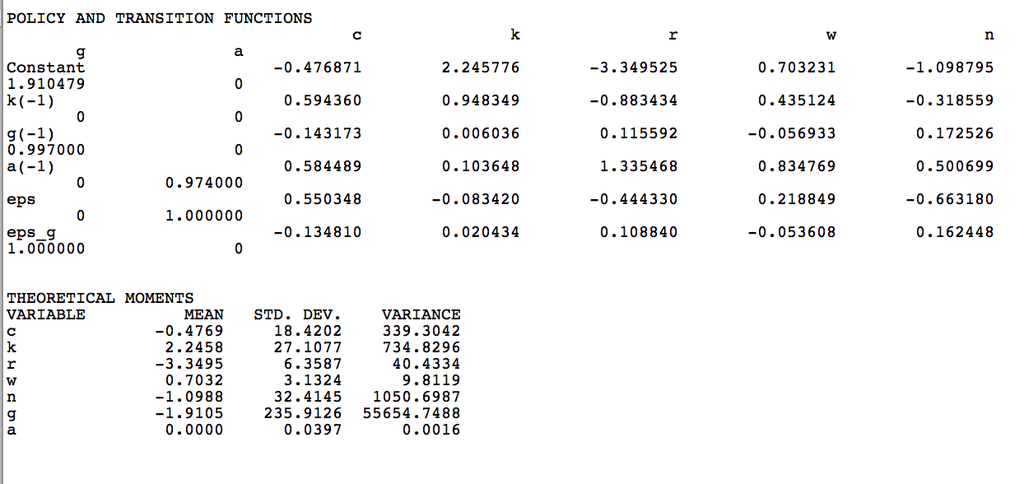

```python
from IPython.display import Image
from IPython.core.display import HTML
Image(filename ="policy_func.png", width=500, height=500)
```

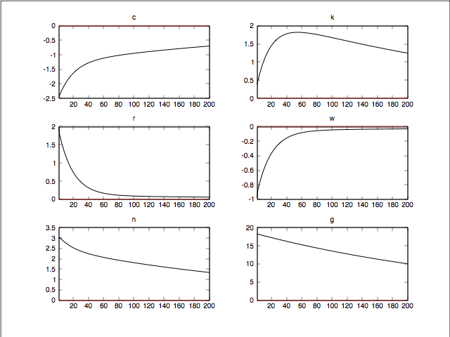

```python
Image(filename ="impulse_responses.png", width=500, height=500)
```

Inclusion of government spending shocks increases variances of the variables, which behave far too smoothly in the traditional RBC model.